# Occupational Mobility Spring 2022

Ken-Hou Lin

19 March, 2022

# Overview

This memo presents the current state of the project. I start by discussing some possible research questions regarding the connection between workplace co-presence and between-occupation mobility. I then describe how the data set is constructed and some empirical patterns.

# Theoretical Starting Points

Why do we observe more mobility from some occupations to some others?

Existing studies on occupational mobility tends to focus on how the level of mobility has changed over time at the aggregate, few systematically examine labor market wise mobility patterns.

The obvious determinant for between-occupation mobility is the level of skill similarity. The more similar skills two occupations require, the higher mobility we should observe between the two occupations.

Besides skills or occupation contents, similarity in sex and educational composition could also facilitate mobility between occupations.

Yet, skill and composition similarities explain does not account for off-diagonal mobility, where the origin and destination occupations may require substantially different skills or have different composition. To understand toff-diagonal mobility, we should consider beyond occupations’ skill or task contents but how they are embedded in organizational contexts.

The idea that workplace adjacency could promote between-occupational mobility is rather intuitive. As individuals work side-by-side with workers of different occupations, one would assume that there would be transfers of skills and occupation-specific knowledge, which could lower the cost of transitioning into a different occupations or bridging the skill gap. It is also common for firms to set up formal rotation among workers through on-the-job training, promotion policies, or internal labor markets, which facilitate the replacement of workers while retaining firm-specific human capital. In sum, it is expected that workplace adjacency could be consequential to the level of mobility between a pair of occupations.

To my knowledge, existing studies have not paid much attention to how between-occupation mobility is linked to organizational contexts at the national level. We may be able to make some claims about how this paper makes contribution showing that between-occupation mobility is sensitive to workplace presence.

The link between mobility and co-presence could have changed over time. An established body of studies in management have shown that the internal labor market and on-the-job training have been declining, while external hires and temporary staffing have been on the rise. As outsourcing becomes more prevalent (buy instead of make), workplaces are also becoming more occupationally homogeneous. This means that 1.) workers may have less direct contact with those in other occupations at their workplaces, and, even in the presence of contact, 2.) there are more barriers/fewer bridges than before for between-occupation mobility.

Certain skill barriers could be more easily bridged by co-presence since these skills tend not to be transmitted through formal but on-the-job training.

# Data Construction

We combine the OES co-presence data with the CPS mobility data at 5 time points (2005, 2008, 2011, 2014, 2017). The co-presence measure for OCC A to OCC B represents the proportion of coworkers for individuals in OCC A are in OCC B. There is also a separate estimate for the proportion of workers in each occupation that work in a single-worker establishment (isolation).

To rule out that the association between co-presence and mobility is due to skill and demographic sorting (i.e., similarly workers are more likely to work in the same establishment), we augment the data set with skill measures from the O*NET and demographic measures from the CPS.

To distinguish different types of mobility, we classify Occ A -> Occ B as downward mobility if the median wage of Occ B is lower than 80% of that of Occ A in both 2005 and 2017. We classify it as upward mobility if the median wage of Occ B is higher than 120% of that of Occ A in both 2005 and 2017. I wonder whether these thresholds are too strict and these thresholds are something to revisit.

```r
w<-read_dta("CPS_OES_3YR_WIDE.dta")
l<-read_dta("CPS_OES_3YR_LONG.dta")
i<-read_dta("OES_SHARE_ISOLATED.dta")
```

# Variables and Trends

I first take a look at the co-presence and mobility variables and some trends.

## Secular Decline in Co-presence

```r
par(mfrow=c(1,2))

exp<-rep(0,5)
for (i in 1:5){
  j=i*3+2002
  exp[i]<-weighted.mean(l$exp[l$year==j],l$sendsize[l$year==j])
}
(exp[5]-exp[1])/exp[1]
```

```
## [1] -0.02472563
```

```r
plot(seq(2005,2017,3),exp,type="b",xlab="Year",ylab="Weighted Average Co-presence",col=pcolor1[1],
     main="Average Co-presence")
grid()

iso<-rep(0,5)
for (i in 1:5){
  j=i*3+2002
  iso[i]<-weighted.mean(l$iso[l$year==j],l$sendsize[l$year==j])
}
(iso[5]-iso[1])/iso[1]
```

```
## [1] 0.1889417
```

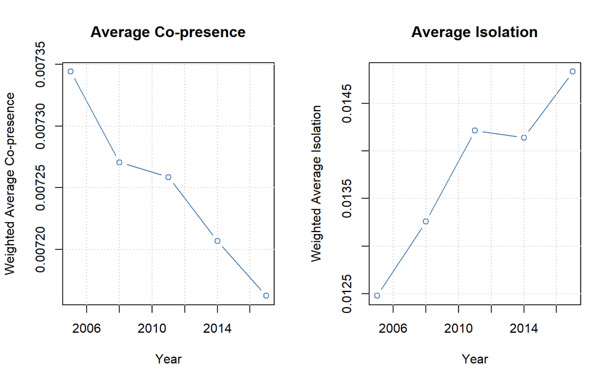

```r
plot(seq(2005,2017,3),iso,type="b",xlab="Year",ylab="Weighted Average Isolation",col=pcolor1[1],
     main="Average Isolation")
grid()
```

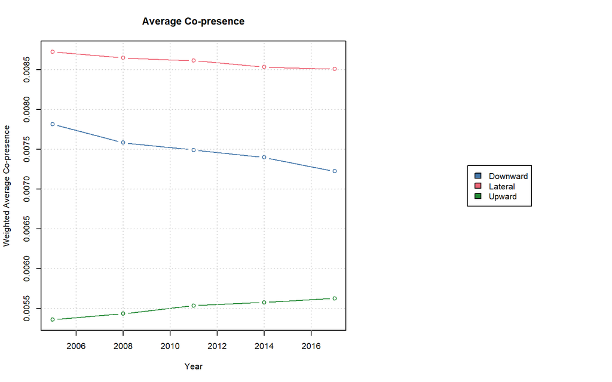

```r
mlab<-c("Downward","Lateral","Upward")
layout(matrix(c(1,1,1,2,2),ncol=5))
exp<-matrix(rep(0,15),ncol=5)
for (i in 1:5){
  j=i*3+2002
  exp[1,i]<-weighted.mean(l$exp[l$year==j & l$mob_type==1],l$sendsize[l$year==j & l$mob_type==1])
  exp[2,i]<-weighted.mean(l$exp[l$year==j & l$mob_type==2],l$sendsize[l$year==j & l$mob_type==2])
  exp[3,i]<-weighted.mean(l$exp[l$year==j & l$mob_type==3],l$sendsize[l$year==j & l$mob_type==3])
}

plot(seq(2005,2017,3),exp[1,],type="b",xlab="Year",ylab="Weighted Average Co-presence",col=pcolor1[1],
     main="Average Co-presence",ylim=c(min(exp),max(exp)))
points(seq(2005,2017,3),exp[2,],type="b",xlab="Year",ylab="Weighted Average Co-presence",col=pcolor1[2])
points(seq(2005,2017,3),exp[3,],type="b",xlab="Year",ylab="Weighted Average Co-presence",col=pcolor1[3])
grid()

plot.new()
legend("center",mlab,fill=pcolor1[1:3])
```

Here we decompose the trends into three types of co-presence. It shows that occupations of similar median wages are more likely to situate in the same workplace. This type of co-presence has declined slightly over time. The second most prevalent co-presence is that co-workers belong to lower-wage occupations, which experienced the most decline. This trend is consistent with the outsourcing story. The least prevalent is that co-workers belong to higher-wage occupations, which experienced some increase.

It makes sense to me that downward co-presence is more prevalent than upward co-presence if most establishments have a pyramid-like wage structure, where the least-paid occupations have most workers. Yet, it is not immediate clear to me why the upward co-presence did not also decline as the downward co-presence.

## Cyclical Mobility Trends

```r
flow<-rep(0,5)
for (i in 1:5){
  j=i*3+2002
  flow[i]<-weighted.mean(l$flow[l$year==j],l$sendsize[l$year==j])
}
(flow[5]-flow[1])/flow[1]
```

```
## [1] 0.04292822
```

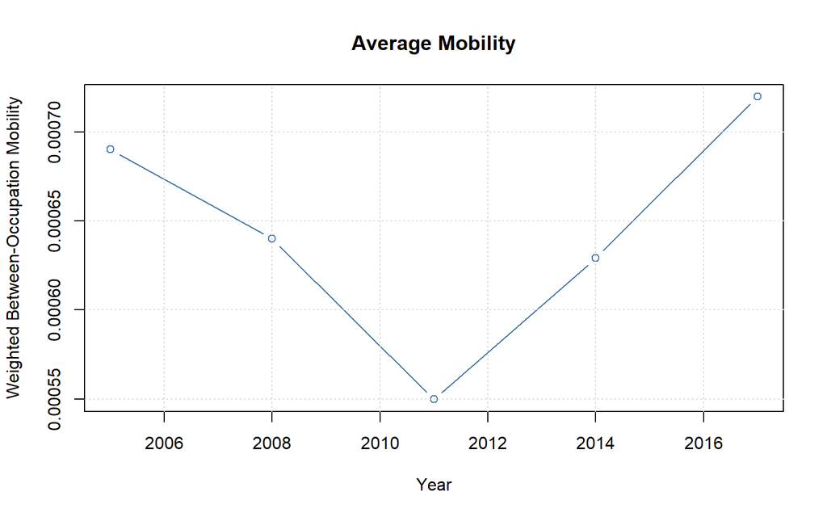

```r
plot(seq(2005,2017,3),flow,type="b",xlab="Year",ylab="Weighted Between-Occupation Mobility",col=pcolor1[1],
     main="Average Mobility")
grid()
```

The between-occupation mobility declined during the Great Recession and has recovered by 2017. Since the recession is the most salient shock to the mobility trend, I don’t think we can tell a story about long-term changes. Although we have 5 time points, the story probably will mostly be cross-sectional.

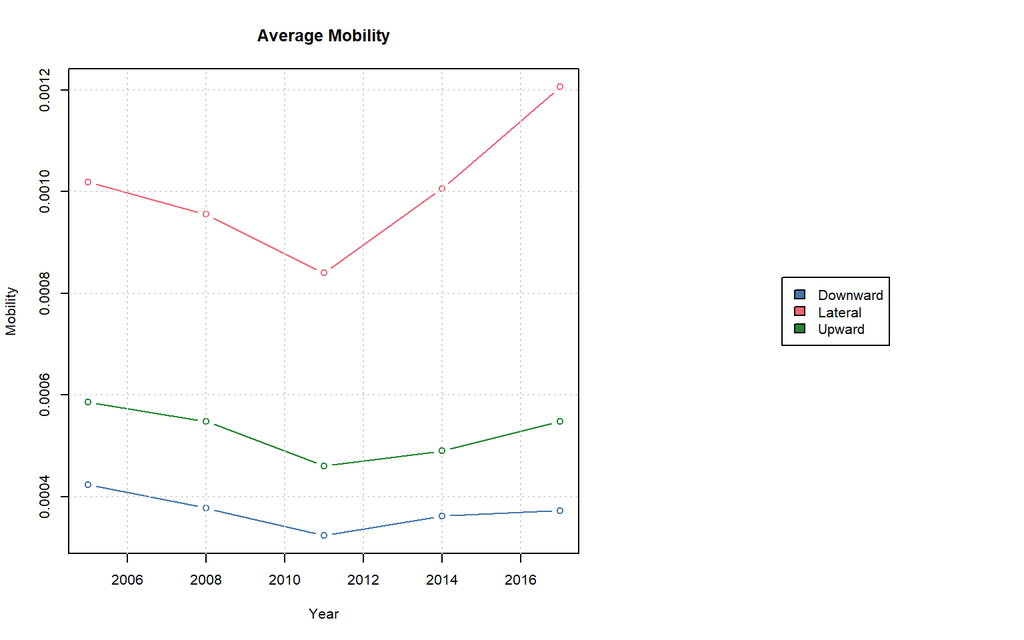

```r
layout(matrix(c(1,1,1,2,2),ncol=5))
flow<-matrix(rep(0,15),ncol=5)
for (i in 1:5){
  j=i*3+2002
  flow[1,i]<-weighted.mean(l$flow[l$year==j & l$mob_type==1],l$sendsize[l$year==j & l$mob_type==1])
  flow[2,i]<-weighted.mean(l$flow[l$year==j & l$mob_type==2],l$sendsize[l$year==j & l$mob_type==2])
  flow[3,i]<-weighted.mean(l$flow[l$year==j & l$mob_type==3],l$sendsize[l$year==j & l$mob_type==3])
}

plot(seq(2005,2017,3),flow[1,],type="b",xlab="Year",ylab="Mobility",col=pcolor1[1],
     main="Average Mobility",ylim=c(min(flow),max(flow)))
points(seq(2005,2017,3),flow[2,],type="b",xlab="Year",ylab="Mobility",col=pcolor1[2])
points(seq(2005,2017,3),flow[3,],type="b",xlab="Year",ylab="Mobility",col=pcolor1[3])
grid()

plot.new()
legend("center",mlab,fill=pcolor1[1:3])
```

Most mobility occurs between occupations of similar wages, which is expected. Upward mobility is more prevalent than downward mobility. Among the three, only lateral mobility actually recovered.

## Correlation between Co-presence and Mobility

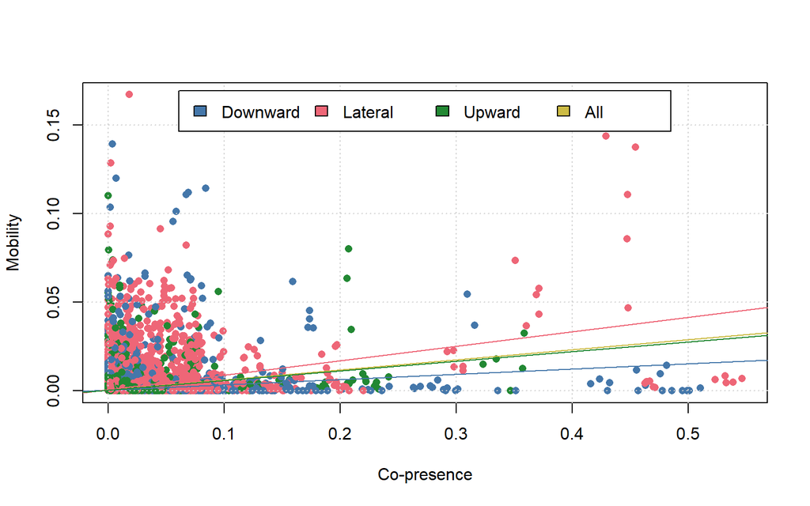

```r
plot(l$exp,l$flow,xlab="Co-presence",ylab="Mobility",col=pcolor1[l$mob_type],pch=16)
grid()
abline(lm(flow ~ exp, data = l), col=pcolor1[4])
abline(lm(flow[mob_type==1] ~ exp[mob_type==1], data = l), col=pcolor1[1])
abline(lm(flow[mob_type==2] ~ exp[mob_type==2], data = l), col=pcolor1[2])
abline(lm(flow[mob_type==3] ~ exp[mob_type==3], data = l), col=pcolor1[3])

legend("top",c("Downward","Lateral","Upward","All"),fill=pcolor1[1:4],inset=0.025,ncol=4)
```

Here I pool all the data points across the 5 time points to examine the correlation between co-presence and mobility. I also distinguish these data points by mobility type, similar to before.

In general, there is a positive correlation between co-presence and mobility (r=0.2667164). The correlation is highest in the case of lateral mobility (r=0.3321524), followed by upward mobility (r=0.2714053). The correlation is weakest in the case of downward mobility (r=0.1698453). The pattern is consistent with early discussion about how co-presence promotes upward mobility more than downward mobility.

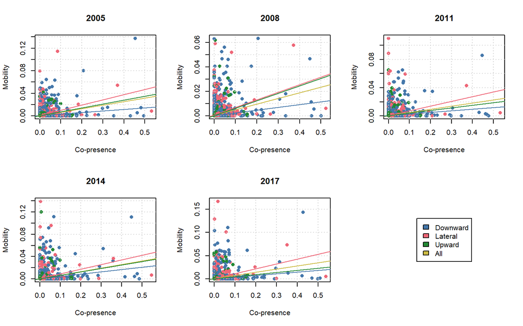

```r
par(mfrow=c(2,3))

for (i in 1:5){
  j=2002+i*3
  plot(l$exp[l$year==j],l$flow[l$year==j],xlab="Co-presence",ylab="Mobility",col=pcolor1[l$mob_type],pch=16,main=j)
  grid()
  abline(lm(flow[l$year==j] ~ exp[l$year==j], data = l), col=pcolor1[4])
  abline(lm(flow[mob_type==1 & l$year==j] ~ exp[mob_type==1 & l$year==j], data = l), col=pcolor1[1])
  abline(lm(flow[mob_type==2 & l$year==j] ~ exp[mob_type==2 & l$year==j], data = l), col=pcolor1[2])
  abline(lm(flow[mob_type==3 & l$year==j] ~ exp[mob_type==3 & l$year==j], data = l), col=pcolor1[3])
}

plot.new()
legend("center",c("Downward","Lateral","Upward","All"),fill=pcolor1[1:4],inset=0.025)
```

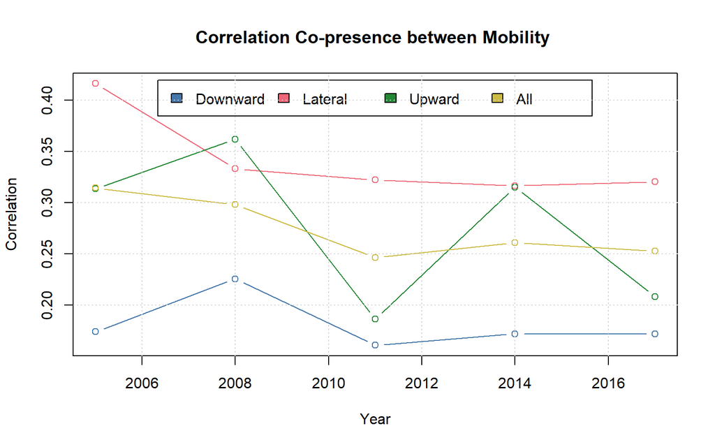

```r
r<-matrix(rep(0,20),ncol=5)

for (i in 1:5){
  for (k in 1:3){
    j=2002+i*3
    r[k,i]<-cor(l$exp[l$mob_type==k & l$year==j],l$flow[l$mob_type==k & l$year==j])
  }
  r[4,i]<-cor(l$exp[ l$year==j],l$flow[ l$year==j])
}

plot(seq(2005,2017,3),r[1,],col=pcolor1[1],type="b",
     xlab="Year",ylab="Correlation",ylim=c(min(r),max(r)),main="Correlation Co-presence between Mobility ")
points(seq(2005,2017,3),r[2,],col=pcolor1[2],type="b")
points(seq(2005,2017,3),r[3,],col=pcolor1[3],type="b")
points(seq(2005,2017,3),r[4,],col=pcolor1[4],type="b")

legend("top",c("Downward","Lateral","Upward","All"),fill=pcolor1[1:4],inset=0.025,ncol=4)

grid()
```

The correlation between co-presence and mobility has declined over time. The trend for upward mobility seems most related to the recession and has not recovered from the recession. Again, we probably can’t tell a story about long-term changes as originally planned. Below I propose some potential arguments for this paper.

# Main Findings

## Workplace Co-presence is robustly correlated with mobility conditional on composition and skill dissimilarities.

I estimate the following equation:

$$F_{i->j}=C_{i->j}+\sum_{m}^{M}(D_m+S_m)$$
$$D_m=|A_{m,i}-A_{m,j}|\ if \ A_{m,i}-A_{m,j}<0; \ otherwise, 0 \\$$
$$S_m=|A_{m,i}-A_{m,j}|\ if \ A_{m,i}-A_{m,j}>0; \ otherwise, 0$$

Where $F_{i->j}$ denotes the directional flow from Occupation i to Occupation j measured as probability. $C_{i->j}$ denotes the proportion of co-workers of people in Occupation i are in Occupation j.

$sum_{m}^{M}(D_m+S_m)$ denotes a series of composition or skill dissimilarities, where $D_m$ represents the absolute difference in occupational attribute $A_m$ when Occupation i has lower $A_m$ than Occupation j, and 0 otherwise. $S_m$ represents the absolute difference in occupational attribute $A_m$ when Occupation i has higher $A_m$ than Occupation j, and 0 otherwise. For any $i->j$, either $D_m$ or $S_m$ needs to be zero.

The idea here is that occupational differences could have asymmetrical effects on mobility. For example, we are likely to observe more mobility from lower-wage occupations to higher-wage occupations than the opposite. In this specific case, we would expect $D_{wage}$ to have a larger coefficient than $S_{wage}$.

For now, I will use the following 5 dimensions of task content: Quantitative, Analytic, Non-routine Interactive, Routine Cognitive, and Manuel. I exclude Verbal because it’s highly correlated with Analytic, and moderately correlated with Non-routine Interactive. I am still thinking about which task/skill measures to use.

I also look into composition differences in sex, race, and median logged wage.

The model also includes period dummies for the five period. Estimates are weighted by occupation size.

```r
t1<-read.csv("table1.csv")
colnames(t1)<-c("Variable","Coefficent","Robust SE")



lab<-c("% Male"," % White","Median Log Wage",
       "Quantitative", "Analytic","Non-Routine Inter","Routine Cognitive","Manual")
labd<-paste("D",lab)
labs<-paste("S",lab)
m<-rbind(labd,labs)
k<-as.vector(m)
t1[2:18,1]<-c("co-presence",k)


print(t1)
```

```
##                             Variable     Coefficent    Robust SE
## 1                                  =          =flow            =
## 2                        co-presence     =0.0393***   =(0.00450)
## 3                           D % Male  =-0.000987*** =(0.0000735)
## 4                           S % Male  =-0.000770*** =(0.0000778)
## 5                         D  % White     =-0.000166  =(0.000149)
## 6                         S  % White   =0.000735***  =(0.000123)
## 7                  D Median Log Wage  =-0.000293*** =(0.0000795)
## 8                  S Median Log Wage   =-0.00115*** =(0.0000732)
## 9                     D Quantitative =-0.0000819*** =(0.0000193)
## 10                    S Quantitative  =-0.000130*** =(0.0000197)
## 11                        D Analytic   =-0.000173** =(0.0000616)
## 12                        S Analytic   =0.000272*** =(0.0000564)
## 13               D Non-Routine Inter  =-0.000540*** =(0.0000426)
## 14               S Non-Routine Inter  =-0.000599*** =(0.0000406)
## 15               D Routine Cognitive  =-0.000313*** =(0.0000554)
## 16               S Routine Cognitive    =-0.0000525 =(0.0000672)
## 17                          D Manual  =-0.000370*** =(0.0000355)
## 18                          S Manual  =-0.000303*** =(0.0000384)
## 19                           =0.year             =0         =(.)
## 20                           =3.year    =-0.0000391 =(0.0000407)
## 21                           =6.year   =-0.000130** =(0.0000398)
## 22                           =9.year    =-0.0000489 =(0.0000444)
## 23                          =12.year     =0.0000341 =(0.0000499)
## 24                            =_cons    =0.00163*** =(0.0000795)
## 25                                =N         =40950            =
## 26                             =R-sq         =0.132            =
## 27   =Standard errors in parentheses
## 28 =* p<0.05, ** p<0.01, *** p<0.001
```

The headline number is that co-presence is positively associated with between-occupation flow when taking into account a variety of occupational differences.

- Differences in sex composition blocks both ways (i.e., both the coefficients of $D$ and $S$ are negative).
- There is more mobility from occupations with more whites to occupations with less whites.
- Wage difference restricts both way. There is less mobility from occupations with higher wages to those with lower wages.
- Quantitative skill difference restricts mobility both ways.There is less mobility from occupations with more quantitative tasks to those with less.
- There is less mobility from occupations requiring less analytic skills to those requiring more.There is more mobility from occupations requiring more analytic skills to those requiring less.
- Non-routine interaction skill difference restrict both ways.
- Routine cognitive tasks could be thought of as clerical work, repetitive but precise. There is less mobility from occupations with less routine cognitive tasks to those with more.
- Difference in manual skills restricts both ways. The blockage is more salient for moving from lower manual occupations to higher manual occupations.
- The coefficients associated with year show a significant drop in mobility during the recession.

Overall, the estimates here support that co-presence, composition, and skill differences are associated with the level of mobility between occupations. The R-sq is about 0.13, which is higher than what I expected.

Sex, quantitative skill, non-routine interaction, and manual tasks are the main dividers that deter occupational mobility.

People tend not move to lower-wage occupations.

Analytic skills work like an one-way turnstile. I should think about why more.

## Workplace Co-presence promotes mobility to higher-wage occupations but not lower-wage occupations.

It’s reasonable to expect that the effect of co-presence on mobility is directional regarding wage difference. That is, we should see a stronger association between co-presence on mobility when the origin occupation has a lower median wage than the destination occupation than the other way around.

We can test this idea by modifying the previous model with interaction terms:

$$F_{i->j}=C_{i->j} + D_{wage} + S_{wage}+ C_{i->j}*D_{wage} + C_{i->j}*S_{wage} +\sum_{m}^{M}(D_m+S_m)$$

```r
t2<-read.csv("table2.csv")
colnames(t2)<-c("Variable","Coefficent","Robust SE")
t2<-t2[c(1:4,6:7,10:13),]


t2[2:6,1]<-c("co-presence","D Median Wage","D Median Wage X Co-presence",
              "S Median Wage", "S Median Wage X Co-presence")


print(t2)
```

```
##                             Variable    Coefficent    Robust SE
## 1                                  =         =flow            =
## 2                        co-presence    =0.0554***   =(0.00749)
## 3                      D Median Wage  =-0.000294**  =(0.000108)
## 4        D Median Wage X Co-presence    =0.0000988    =(0.0215)
## 6                      S Median Wage =-0.000645*** =(0.0000919)
## 7        S Median Wage X Co-presence   =-0.0740***   =(0.00965)
## 10                                =N        =40950            =
## 11                             =R-sq        =0.149            =
## 12   =Standard errors in parentheses
## 13 =* p<0.05, ** p<0.01, *** p<0.001
```

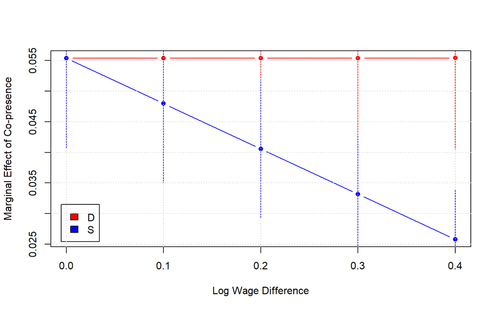

```r
d<-read_dta("wage_margins.dta")
ymax<-max(c(d$u_mar,d$d_mar))
ymin<-min(c(d$u_mar,d$d_mar))
plot(d$difference,d$u_mar,type="b",col="red",pch=16,
     ylim=c(ymin,ymax),xlab="Log Wage Difference",ylab="Marginal Effect of Co-presence")
points(d$difference,d$d_mar,type="b",col="blue",pch=16)
segments(d$difference,d$u_mar+1.96*d$u_marse,d$difference,d$u_mar-1.96*d$u_marse,col="red")
segments(d$difference,d$d_mar+1.96*d$d_marse,d$difference,d$d_mar-1.96*d$d_marse,col="blue")

legend("bottomleft",c("D","S"),fill=c("red","blue"),inset=0.025)
grid()
```

The interpretation for the interaction of two continuous variables is always tricky and the splines implemented here definitely complicates the interpretation further. I decided to plot the marginal effect of co-presence by $D$ and $S$. It shows that the positive association between co-presence remains robust when the destination occupation has a higher median wage, but declines when the destination occupation has a lower median wage. In sum, co-presence promotes upward and lateral mobility but less downward mobility.

## Workplace Co-presence reduces some skill barriers in between-occupation mobility.

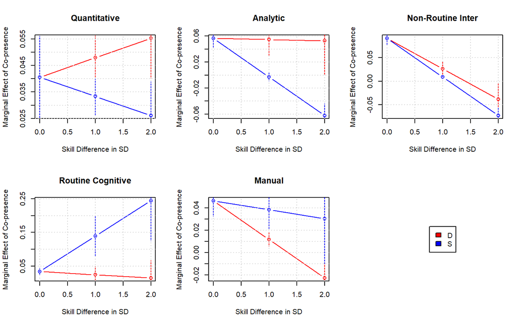

```r
varlist<-c("_aa_qn", "_aa_ay", "_aa_ni","_aa_rc", "_aa_mn")
varlab<-c("Quantitative","Analytic","Non-Routine Inter","Routine Cognitive","Manual")

par(mfrow=c(2,3))

for(i in 1:5){
filename<-paste0(varlist[i],"_margins.dta")
data<-read_dta(filename)
m<-as.matrix(data)
ymax<-max(m[,c(10,12)])
ymin<-min(m[,c(10,12)])

plot(data$difference,m[,10],type="b",col="red",
     xlab="Skill Difference in SD",ylab="Marginal Effect of Co-presence",ylim=c(ymin,ymax),main = varlab[i])
grid()
points(data$difference,m[,10],type="b",col="red")
points(data$difference,m[,12],type="b",col="blue")

segments(data$difference,m[,10]+1.96*m[,11],data$difference,m[,10]-1.96*m[,11],col="red")
segments(data$difference,m[,12]+1.96*m[,13],data$difference,m[,12]-1.96*m[,13],col="blue")
grid()
}

plot.new()
legend("center",c("D","S"),fill=c("red","blue"))
```

Similarly to above, I plot the marginal effect of co-presence on directional flow in two scenarios: when the destination occupation requires more of a certain skill ($D$) and when the destination requires less of a certain skill ($S$).

The results here show that co-presence bridges the quantitative skill gap when the origin occupation has lower quantitative skills. The positive slope for $D$ suggests that co-presence could reduce the constraint generated by skill deficit.

The pattern for analytic skill is similar to wage. The effect of co-presence is robust when the destination requires higher analytic skill and declines when the destination requires less analytic skill. I also just feel this skill measure approximates class/status.

We see a very different pattern for non-routine interaction and manual. The marginal effect of exposure drops in both $D$ and $S$ for these 2 cases, suggesting that co-presence does not facilitate mobility when there is a substantial skill gap. Between the two, manual makes more sense to me since people don’t want to go into occupations demanding high manual skills even there’s co-presence. I would expect non-routine interaction will behave more similarly to the first three cognitive skills but apparently not.

Co-presence seems to help people escaping occupations with a lot of routine cognitive tasks but does not facilitate people entering these occupations.

Again, I am skill thinking about how to theorize about skills and which skills should be incorporated. In general, I would expect co-presence to have a larger effect on mobility for $D$ when the skill/task is “desirable,” and a larger effect for $S$ when the skill/task is not “desirable.”

# Concluding Thoughts

While I originally was interested in structural trend, the period of analysis seems too short for us to tell a story about how the decline in co-presence leads to a decline in mobility, especially when the mobility trend is highly impacted by the Great Recession. Correct me if I am wrong, but it seems difficult to harmonize the new OES occupation categories to the ones before 2003, which is the main obstacle for us to extend the period of analysis.

That said, I think a cross-sectional analysis on how co-presence could bridge skill gaps is interesting. If this is the direction we should take, I wonder whether pooling more years of OES data together may generate more precise estimates for co-presence. This is unclear to me because the OES sample seems already large. On the CPS side, pooling more years together certainly helps.

My plan is to do more descriptive analysis to think through the relationship between co-presence and mobility, especially looking into extreme cases. I also want to take more time thinking about skills.

Most importantly, I’m very much interested in learning about your thoughts on what we have so far.